# Modeling and prediction for movies

Last compiled: May 10, 2017

## Setup

### Packages and Reproducibility

In this project, the `dplyr` package by Wickham and Francois (2016) is used to explore the data. Visualization of the data is accomplished with the `ggplot2` package created by Wickham and Chang (2016). The data is from (“Rotten Tomatoes: Movies TV Shows Movie Trailers Reviews” 2016) and (“IMDb - Movies, TV and Celebrities” 2016). This document is written with R Markdown using the `rmarkdown`, `knitr`, and `bookdown` packages written by Allaire et al. (2017), Xie (2016b), and Xie (2016a), respectively.

```r
# load all packages used
library(ggplot2)
library(dplyr)
```

#### Load data

```r
load("movies.RData")
```

## Part 1: Data

This is an observational study and an experiment is not conducted to collect data and as such random assignment was not used. Therefore, we cannot establish causality.Random assignment appears to be used within these particular data sets. A random amount of people were surveyed concerning their various biases concerning various elements of a film. Each person was randomly chosen to be representative the larger population of movie goers. The selection can then be used to determine associations between the different variables presented within a film. For instance this survey of movie goers may provide insight into an audiences preferred genre or their preferred way of critiquing said film. Random sampling is almost impossible to achieve in a setting such as this simply because ethics come into play. Random assignment on the other other hand can help researchers detect relationships by the usage of treatment and control groups but it cannot determine causality in most cases.

## Part 2: Research question

The analysis in this document is intended to answer the following research question based on the movies dataset: Is there association between audience score and critics score and imdb_rating? By answering this proposed question it can help confirm my assumption that critic rating can be reliably used to predict audience rating.

## Part 3: Exploratory data analysis

```r
nrow(movies)
```

```
[1] 651
```

```r
ncol(movies)
```

```
[1] 32
```

```r
summary(movies$critics_score)
```

```
   Min. 1st Qu.  Median    Mean 3rd Qu.    Max.
   1.00   33.00   61.00   57.69   83.00  100.00
```

```r
summary(movies$audience_score)
```

```
   Min. 1st Qu.  Median    Mean 3rd Qu.    Max.
  11.00   46.00   65.00   62.36   80.00   97.00
```

```r
summary(movies$imdb_rating)
```

```
   Min. 1st Qu.  Median    Mean 3rd Qu.    Max.
  1.900   5.900   6.600   6.493   7.300   9.000
```

```r
T1 <- xtabs(~title_type + mpaa_rating, data = movies)
knitr::kable(T1, caption = "Flim rating for film types", booktabs = TRUE)
```

Table 1: Flim rating for film types

|  | G | NC-17 | PG | PG-13 | R | Unrated |
| --- | --- | --- | --- | --- | --- | --- |
| Documentary | 3 | 0 | 8 | 3 | 9 | 32 |
| Feature Film | 16 | 2 | 110 | 130 | 317 | 16 |
| TV Movie | 0 | 0 | 0 | 0 | 3 | 2 |

Table 1 is a contingency table of film type and film rating.

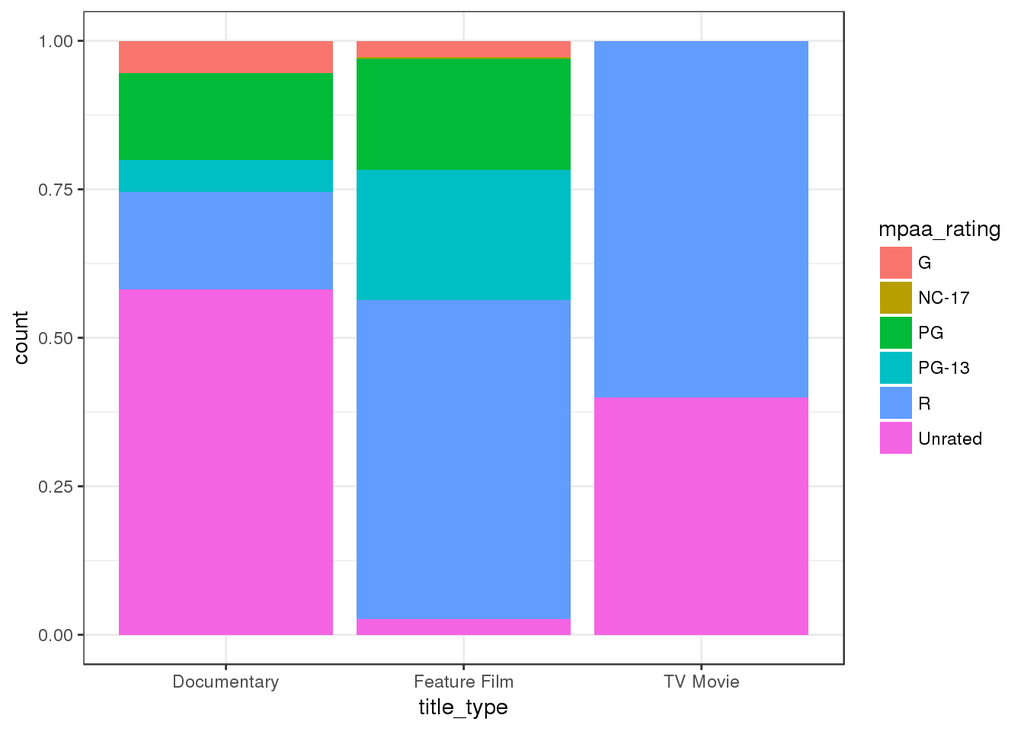

Figure 1: Depiction of the rating for particular titles

```r
ggplot(data = movies, aes(x = title_type, fill = mpaa_rating)) +
   geom_bar(position = "fill") +
   theme_bw()
```

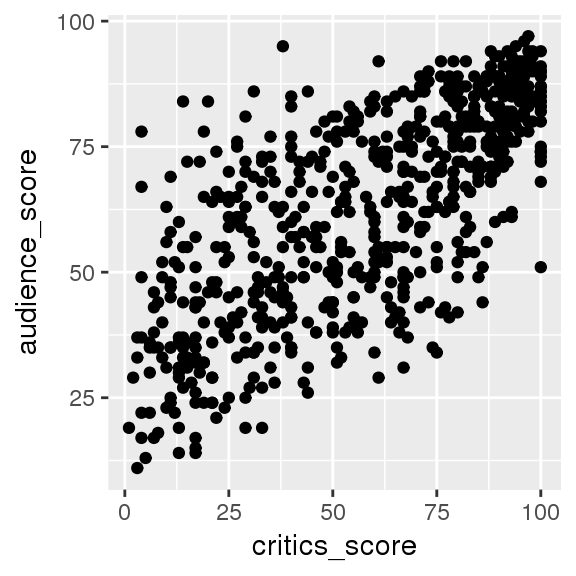

[figure not shown]

Figure 2: Scatterplot of `audience_score` versus `critics_score`

```r
ggplot(data = movies, aes(x = critics_score, y = audience_score)) +
  geom_point()
```

The scatter plot of critics_score vs audience_score is shown above. The second plot also includes a linear model fit to the data to explore the relationship between the two variable. These plots appear to show that there is a positive linear relationship between the two variables. This result is helpful to answer the research question and we need to do further statistical analysis.

[figure not shown]

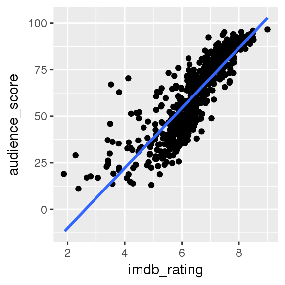

```r
ggplot(data = movies, aes(x = imdb_rating, y = audience_score)) +
  geom_jitter() +  geom_smooth(method = "lm", se = FALSE)
```

The scatter plot of imdb_rating vs audience_score is shown above. The second plot also includes a linear model fit to the data to explore the relationship between the two variable. It can easily be observed from these plots that there is a positive linear relationship between the two variables.

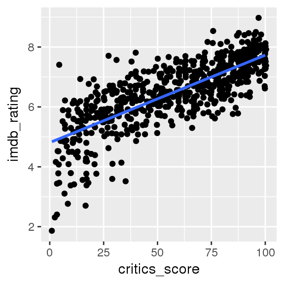

```r
ggplot(data = movies, aes(x = critics_score, y = imdb_rating)) +
  geom_jitter() +  geom_smooth(method = "lm", se = FALSE)
```

## Part 4: Modeling

The `audience_score` and `critics_score` and `imdb_rating` were considered for the full model. Other variables were excluded from the full models because some are for information only. Others were excluded because they simply did not make sense to include in the analysis. `Audience_score` and `critics_score` and `imdb_rating` were selected because the research question was to address if there association between audience score and critic score.

A linear model was fit to determine the relationship between the `audience_score` and `critics_score` and `imdb_rating` to answer the research question.

```r
lmfit <- lm(movies$audience_score ~ movies$critics_score + movies$imdb_rating)
summary(lmfit)
```

```
Call:
lm(formula = movies$audience_score ~ movies$critics_score + movies$imdb_rating)

Residuals:
    Min      1Q  Median      3Q     Max
-26.668  -6.758   0.723   5.513  52.438

Coefficients:
                      Estimate Std. Error t value Pr(>|t|)
(Intercept)          -37.03195    2.86401 -12.930  < 2e-16 ***
movies$critics_score   0.07318    0.02161   3.386 0.000753 ***
movies$imdb_rating    14.65760    0.56590  25.901  < 2e-16 ***
---
Signif. codes:  0 '***' 0.001 '**' 0.01 '*' 0.05 '.' 0.1 ' ' 1

Residual standard error: 10.08 on 648 degrees of freedom
Multiple R-squared:  0.7524,    Adjusted R-squared:  0.7516
F-statistic: 984.4 on 2 and 648 DF,  p-value: < 2.2e-16
```

The relationship between these particular variables appears to be quite strong as shown by R-Squared value and the probability. However, we need to check if the explanatory variables are correlated.

```r
lmfit2 <- lm( movies$critics_score ~ movies$imdb_rating)
summary(lmfit2)
```

```
Call:
lm(formula = movies$critics_score ~ movies$imdb_rating)

Residuals:
    Min      1Q  Median      3Q     Max
-71.855 -12.803   3.116  13.694  43.196

Coefficients:
                   Estimate Std. Error t value Pr(>|t|)
(Intercept)        -72.3792     4.3572  -16.61   <2e-16 ***
movies$imdb_rating  20.0317     0.6619   30.26   <2e-16 ***
---
Signif. codes:  0 '***' 0.001 '**' 0.01 '*' 0.05 '.' 0.1 ' ' 1

Residual standard error: 18.31 on 649 degrees of freedom
Multiple R-squared:  0.5853,    Adjusted R-squared:  0.5846
F-statistic: 915.9 on 1 and 649 DF,  p-value: < 2.2e-16
```

As shown in the results above there is evidence that there is moderately strong relationship between the two explanatory variables. These variables are collinear and adding more than one of these variables to the model would not add much value to the model. As a result only `critics_score` is selected as explanatory variable and the model is reconstructed again. It is expected to see a strong relationship between `imdb_rating` and `audience_score`, since they are both based on audience rating. Therefore it is reasonable to select `critics_score` as an explanatory variable to answer the research question.

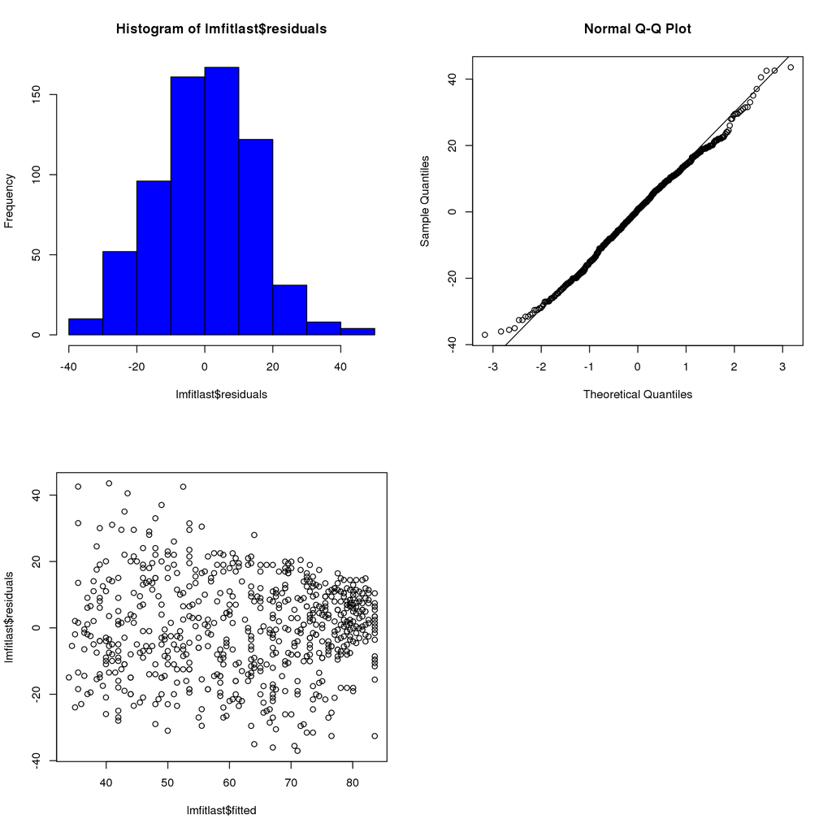

```r
lmfitlast <- lm(audience_score ~ critics_score, data = movies)
par(mfrow=c(2,2))
hist(lmfitlast$residuals, col="blue")
qqnorm(lmfitlast$residuals)
qqline(lmfitlast$residuals)
plot(lmfitlast$residuals ~ lmfitlast$fitted)
#plot(abs(lmfitlast$residuals ~ lmfitlast$fitted))
```

```r
summary(lmfitlast)
```

```
Call:
lm(formula = audience_score ~ critics_score, data = movies)

Residuals:
    Min      1Q  Median      3Q     Max
-37.043  -9.571   0.504  10.422  43.544

Coefficients:
              Estimate Std. Error t value Pr(>|t|)
(Intercept)   33.43551    1.27561   26.21   <2e-16 ***
critics_score  0.50144    0.01984   25.27   <2e-16 ***
---
Signif. codes:  0 '***' 0.001 '**' 0.01 '*' 0.05 '.' 0.1 ' ' 1

Residual standard error: 14.37 on 649 degrees of freedom
Multiple R-squared:  0.496, Adjusted R-squared:  0.4952
F-statistic: 638.7 on 1 and 649 DF,  p-value: < 2.2e-16
```

The results shown above indicate that there is strong relationship between critic score and audience score. Also the results show that critic score is a significant predictor (P <2e-16) of audience score. For one unit increase in critic score the audience score increases by 0.5 units.

## Part 5: Prediction

For this portion we will use our model created earlier, lmfitlast to predict the audience score for a new movie, Visioneers, with an average critic score of 70. To do this first, we need to create a new data frame for this movie.

```r
newmovies <- data.frame(title ="Visioneers", critics_score = 70)
predict(lmfitlast, newmovies)
```

```
       1
68.53613
```

After the data frame is created we can do the prediction. This of course uses the `predict` function. Our model predicts that the audience score for Visioneers to be 68.5. This appears to be a reasonable prediction. A prediction interval was also constructed around this prediction. This will provide a measure of uncertainty around the prediction as follows.

```r
predict(lmfitlast, newmovies, interval = "prediction", level = 0.95)
```

```
       fit      lwr      upr
1 68.53613 40.29775 96.77451
```

The model predicts, with 95% confidence, that the new movie, Visioneers, with an average critic score of 70 is expected to have an audience score between 40.3 and 96.8.

## Part 6: Conclusion

A statistical analysis using data from a movie dataset was conducted to determine if there is any association between audience score and critics score. The results of this analysis suggest that there is strong positive linear relationship between critics score and audience score. This analysis also shows that critics score is a significant predictor of audience score. The results show that data on critics score can be used to predict audience satisfaction. By using a more thorough analysis someone can determine which movies to produce that are more liked by the audience.

## References

Allaire, JJ, Joe Cheng, Yihui Xie, Jonathan McPherson, Winston Chang, Jeff Allen, Hadley Wickham, Aron Atkins, Rob Hyndman, and Ruben Arslan. 2017. *Rmarkdown: Dynamic Documents for R*. http://CRAN.R-project.org/package=rmarkdown.

“IMDb - Movies, TV and Celebrities.” 2016. *IMDb*. Accessed July 21. http://www.imdb.com/.

“Rotten Tomatoes: Movies TV Shows Movie Trailers Reviews.” 2016. Accessed July 21. https://www.rottentomatoes.com/.

Wickham, Hadley, and Winston Chang. 2016. *Ggplot2: Create Elegant Data Visualisations Using the Grammar of Graphics*. http://CRAN.R-project.org/package=ggplot2.

Wickham, Hadley, and Romain Francois. 2016. *Dplyr: A Grammar of Data Manipulation*. http://CRAN.R-project.org/package=dplyr.

Xie, Yihui. 2016a. *Bookdown: Authoring Books with R Markdown*. http://CRAN.R-project.org/package=bookdown.

———. 2016b. *Knitr: A General-Purpose Package for Dynamic Report Generation in R*. http://CRAN.R-project.org/package=knitr.